# Exploring TensorFlow neural network framework with the classic NMist handwriting example

### Computers are great!

Computers have come a long way in the last century. There are many problems that are very simple for a computer to answer but would take most humans quite some time. For example: How long would it take you to find the cube root of 373248 or the square root of 5184? I will give you two hints... the answers are the same and my high school football number. Lets see how long it takes a computer?

```python
import timeit
loops = 100000
elapse_cube= timeit.timeit('from math import sqrt; x = 373248;' 'pow(x,1/3)', number=loops)
elapse_square= timeit.timeit('from math import sqrt; x = 5184;' 'sqrt(x)', number=loops)
print 'Average time to calculate: \n cube root: {} seconds \n square root: {} seconds'.format(elapse_cube/loops, elapse_square/loops)
```

```
Average time to calculate:
 cube root: 1.65548086166e-06 seconds
 square root: 1.14530801773e-06 seconds
```

Even if you knew me in high school I bet the computer still wins the race. Turns out that the computer can solve this in about a microsecond. That's 1 millionth of a second ... That's pretty fast.

There are also problems that are not easy for a computer. In fact, if you ask any 5 year old child the difference between a picture of a horse and a sheep instantly they can tell you the different, let alone any other farm animal (thank you Old MacDonald). How is it that a 5 year old child can beat a computer? It turns out that the human brain is an amazing network for processing images. Getting a machiene to do this takes a lot of work and leverages the progress of many scientists throughout the years.

### What is a Neural Network?

A neural network(NN) is effectivly series of connected mathematical pathways. A NN cosnists of collection neutrons that are connected via synapses. Designing a network is takes some skill. The simple explaination of network structure is organized into three main parts: an input layer, a hidden layer, and an output layer. What makes networks 'deep' is the there can be any number of hidden layers between the input and output layer.

[figure not shown]

To help understand this post a little better I recommend looking [here](http://neuralnetworksanddeeplearning.com/chap1.html)

Documentation for [TensorFlow](https://www.tensorflow.org/)

## Let's begin

In this example we are going to construct a 2 different types of networks

- Softmax Regression Model
- multi-layer network with convolution and pooling

The input images are 28X28 pixels. This means the input layer will have 784 channels (one for each pixel 28*28). The final output layer will always have 10 channels which correspond to the neurons for the 10 digits (0-9)

### Softmax Regression Model

```python
# Here we will walk through the MNIST example to learn a little more about tensorflow and how to use the framework
# First load the tensor flow mnist data (This may take a few seconds)
from tensorflow.examples.tutorials.mnist import input_data
mnist = input_data.read_data_sets('MNIST_data', one_hot=True)# This preloads the data sets
```

```
Extracting MNIST_data/train-images-idx3-ubyte.gz
Extracting MNIST_data/train-labels-idx1-ubyte.gz
Extracting MNIST_data/t10k-images-idx3-ubyte.gz
Extracting MNIST_data/t10k-labels-idx1-ubyte.gz
```

```python
# now we import tensorflow
import tensorflow as tf
#set up an interactive session
sess = tf.InteractiveSession()
```

```python
# First we will being with a single layer...
# We need to build nodes for input images and output classes
x = tf.placeholder(tf.float32,shape=[None,784])
y_ = tf.placeholder(tf.float32,shape=[None,10])

# In this case x and y_ are not specific values... just placeholders.
#When we run TF they will be take an imput walue.
# Note that 784 is used becuase it will relate to a 28X28 pixel image
# Note that 10 is used becuase it realates to the length of output number 0-9
```

```python
# Now we have to define weights and biases
# We do this through variable in TF.
W = tf.Variable(tf.zeros([784,10])) # we have 784 imput weights and 10 output classes
b = tf.Variable(tf.zeros([10]))

# to bring these variables into the session we need to initialize
sess.run(tf.global_variables_initializer())
```

```python
# Now we will try to impemnt the model. We do this by taking input images * weights and then adding the bias.
# W*x + b
y = tf.matmul(x,W)+b
```

```python
# now we define the loss fucntion
# loss function is a representation of how bas our model didi
# We want to minimize the loss function

cross_entropy = tf.reduce_mean(tf.nn.softmax_cross_entropy_with_logits(labels = y_, logits=y))
# here we see that labels are the actual labels for the image
# y is the prediction we get from the model
#nn.softmax_cross_entropy_withLogits applies the softmax to the model which is unnoremalized
#Then reduce_mean takes the average over the sums
```

```python
#Now we can train the model
# Use gradient descent with step size 0.5
train_step =tf.train.GradientDescentOptimizer(0.5).minimize(cross_entropy)
# What is going on ?
# compute gradients, compute parameter update steps, and apply update steps to the parameters
```

```python
# Now to train... .we are going to add a batch of photos run the training on them\
# We will replace x and y_ with the actual values from the given batch

for _ in range(1000):
    batch = mnist.train.next_batch(100)# note 100 is batch size
    train_step.run(feed_dict={x:batch[0],y_:batch[1]})# here we are feeding in a dictionary of the x and y_ from the batch
```

```python
# Well... how did we do?
# we would like to figure out in which cases we predicted the correct label
model_label_guess = tf.arg_max(y,1) # this is the label that our model thinks is most likely for each input
label_true = tf.arg_max(y_,1) # This is simply the true label for the imput
# we want to see when they are correct

correct_prediction = tf.equal(model_label_guess,label_true)
# This is a list of booleans

# to findout which are correct [ True, False, True, True,False] This is then cast as floats [1.,0.,1.,1.,0.]
# if we take the mean of this, we call this our accuracy.... how many it predicted correctly

accuracy = tf.reduce_mean(tf.cast(correct_prediction,tf.float32))
accuracy.eval(feed_dict={x:mnist.test.images,y_:mnist.test.labels})
```

```
0.91430002
```

```python
# lets look at the parameter space for changing a few variables.
# here we will just use lists ( since we won't append too much ), then convert to np.arrays and plot some things

# First assume step size ranges from [0,1]: plot as a function of number of training steps
pretty = False
step_size = 0.5 # just a guess to start , from experience
Batch_size = 100 # we have ten number slots 0-9 so 100 batch size should get some represenation of each number
max_steps = 500 #max number of steps ( remember it takes longer to do more)
nstep_step = 10#step_step
import numpy as np
# if you want to make pretty use these

if pretty:
    max_steps = 1000 #max number of steps ( remember it takes longer to do more)
    nstep_step = 10#step_step

# to make life easy, let's keep this like a list of pairs [ [0_step,accuracy_0],[1_step,accuracy_1]... ]
accuracy_for_various_n_steps = []


# we will use zero ( it will be bad ) but it will also be a way to show random probilibty :)

for n_steps in np.arange(0, max_steps, nstep_step):
    #Reset a bunch of things
    sess.run(tf.global_variables_initializer())
    temp_y = tf.matmul(x,W)+b
    temp_cross_entropy = tf.reduce_mean(tf.nn.softmax_cross_entropy_with_logits(labels = y_, logits=temp_y))
    temp_train_step = tf.train.GradientDescentOptimizer(step_size).minimize(temp_cross_entropy)
    for _ in range(int(n_steps)):
        temp_batch = mnist.train.next_batch(Batch_size)
        #Train it
        temp_train_step.run(feed_dict={x:temp_batch[0],y_:temp_batch[1]})
    #how many are correct?
    temp_correct = tf.equal(tf.arg_max(temp_y,1),tf.arg_max(y_,1))
    temp_accuracy = tf.reduce_mean(tf.cast(temp_correct,tf.float32))
    temp_accuracy_eval = temp_accuracy.eval(feed_dict={x:mnist.test.images,y_:mnist.test.labels})
    temp_entry = [n_steps,temp_accuracy_eval]
    accuracy_for_various_n_steps.append(temp_entry)
```

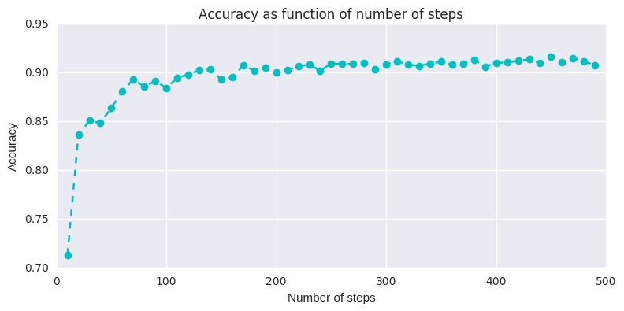

```python
# let's take a look at how the accuracy stacks up.
%matplotlib inline

import numpy as np
import matplotlib
import matplotlib.pyplot as plt

def plot_avs():
    plt.figure(figsize=(9,4))
    avs = np.asarray(accuracy_for_various_n_steps)
    plt.plot(avs[1:,0],avs[1:,1],"co--")
    #plt.scatter(avs[1:,0],avs[1:,1])
    plt.grid(True)
    plt.title("Accuracy as function of number of steps")
    plt.xlabel("Number of steps")
    plt.ylabel("Accuracy")
    plt.show()
plot_avs()
```

### Keep going

#### It should be noted that we are not really we should be looking at the loss function... but I will go over that later on) Let's just make some nice nieve plots

Here we see that even with a few steps in the minimization the accuracy plateaus very quickly. Sometimes changing 'hyper parameters' great effects results. There is no set systematic way tune these paremeters. There are a few geeral rules but by no means are they required.

```python
# a pandas DF would be very useful for the next part....but let's see what we can do with numpy.
# The next plot we will use pandas :)

# So we say that somewhere around 500 steps sounds reasonable... it is probably overkill.
# lets look at some more parts of parameter space

#We would like to see the effect of varying batch size... maybe we simply dont have enough test samples?
# Also: maybe the minimization is too fast or two slow.... Let's vary the step size (0.001,1)

# this will take a little while to run... .but it makes a useful plot
pretty = False
n_training_steps =100 # RG CHANGE THIS BACK TO 500
max_step_size = 1. # descent step size
step_size_step = 0.1 # various steps size
max_batch_size = 100 # how many samples in training
batch_size_step = 10 # various sample size for training

b_size_list = [ z for z in range(0,max_batch_size,batch_size_step) ][1:]# remove 0
s_size_list = np.arange(0,max_step_size,step_size_step)# keep 0.... again more fun math
acc_for_batch_step = [] # for list of list [ [bsize, s_size,acc]....] This might get a little heavy for append. we will see

for b_size in b_size_list:
    for s_size in s_size_list:
        sess.run(tf.global_variables_initializer())
        temp_y = tf.matmul(x,W)+b
        temp_cross_entropy = tf.reduce_mean(tf.nn.softmax_cross_entropy_with_logits(labels = y_, logits=temp_y))
        temp_train_step = tf.train.GradientDescentOptimizer(s_size).minimize(temp_cross_entropy)
        for _ in range(n_training_steps):
            temp_batch = mnist.train.next_batch(b_size)
            #Train it
            temp_train_step.run(feed_dict={x:temp_batch[0],y_:temp_batch[1]})
        #how many are correct?
        temp_correct = tf.equal(tf.arg_max(temp_y,1),tf.arg_max(y_,1))
        temp_accuracy = tf.reduce_mean(tf.cast(temp_correct,tf.float32))
        temp_accuracy_eval = temp_accuracy.eval(feed_dict={x:mnist.test.images,y_:mnist.test.labels})
        temp_entry = [b_size,s_size,temp_accuracy_eval]
        acc_for_batch_step.append(temp_entry)
```

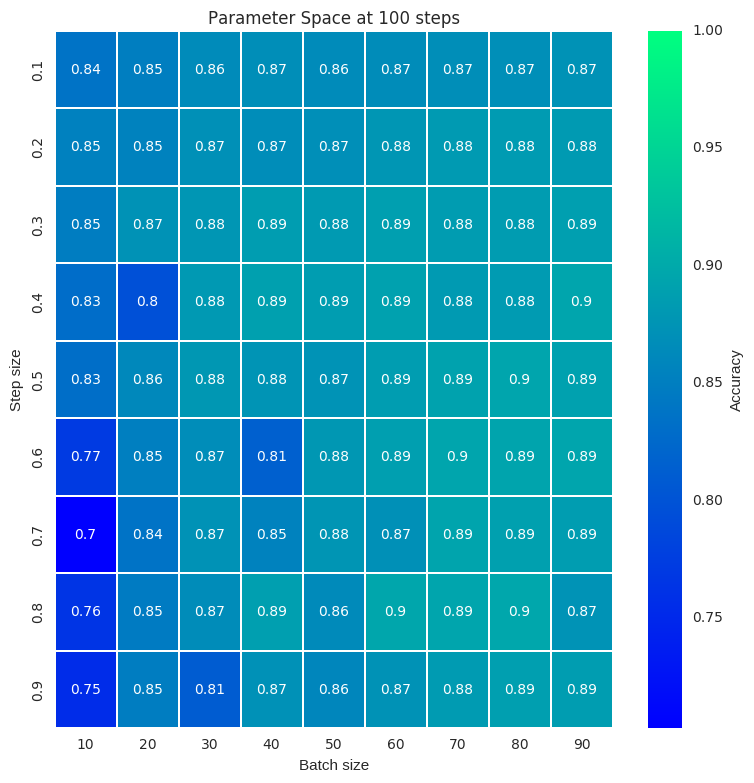

```python
# make kde plot to see effect
# make a scatter plot where weight is the accuracy

#Lets plot this with seaborn. If you do not have seaborn you really need to get it.
import pandas as pd
import seaborn as sns

#make this into a pandas datafream
#Lets drop the instances where stepsize = 0.. we have already seen that 0 step size gives us ~10% aka Random
df = pd.DataFrame(np.asarray(acc_for_batch_step),columns=['Batch size','Step size','acc'])
df['Batch size'] = df['Batch size'].astype(int) # clean it up a little
df_prune = df[(df['Step size'] != 0)]

def plot_heatmap(mydf):
    plt.figure(figsize=(9,9))
    #Let's use pivot to put this into a nice format to view
    df_pivot = mydf.pivot("Step size","Batch size","acc")
    ax = sns.heatmap(df_pivot,vmax=1,linewidths=.5,annot=True,cmap='winter')
    ax.collections[0].colorbar.set_label("Accuracy")
    plt.title("Parameter Space at {} steps".format(n_training_steps))# note to self format is carried from a prior cell
    plt.show()

plot_heatmap(df_prune)

#def plot_bsa():
#    #plot
#    bsa = np.asarray(acc_for_batch_step)
#    plt.scatter(bsa[0:,0],bsa[0:,1],c=bsa[0:,2],marker='s',s=500)
#    plt.show()
#plot_bsa()
```

We could keep going to explore and optimize other areas of parameter space but nothing sticks out as any drastic gains.

## Multilayer Networks

First some termonology:

Convolution layer: takes a given kernal from the input, spans over a given height*width *depth and returns a feature map that is then passed forward in the network

Pooling layer: takes a feature map and reduces the dimensionality effectivly reducing the number of paramters the network needs to learn.

Here is a useful graphic to understand a convolutional layer followed by a pooling layer that then leads to a softmax:

[figure not shown]

Example: if you have 1000 training examples, and your batch size is 500, then it will take 2 iterations to complete 1 epoch.

```python
############### CHANGE IT UP..... DO BETTER

#first we need to make our own weight and bias variables
#weights should have some noise to allow for symetrty breaking .
# if you have all zeros you might get stuck with the gradiant and not go anywhere

def weight_variable(shape):
    initial = tf.truncated_normal(shape,0,1)
    return tf.Variable(initial)

def bias_variable(shape):
    initial = tf.constant(0,1,shape=shape)# note we keep the bias positive to avoid dead nodes
    return tf.Variable(initial)


#first lets define useful functions
def con2d(x,W):
    return tf.nn.conv2d(x,W,strides=[1,1,1,1],padding='SAME')
def max_pool_2X2(x):
    return tf.nn.max_pool(x,ksize=[1,2,2,1],strides=[1,2,2,1],padding='SAME')
```

```python
#now make the first convolution layer.
# we will make is 5X5 , 1 channel with 32 features
# note 32 features is what's called a hyperparameter. It's just a number of features... we can make it anything

W_conv1 = weight_variable([5,5,1,32])
B_conv1 = bias_variable([32]) # note the number of bias is dependednt on number of features

# now reshape the image to a 4d tensor

x_image = tf.reshape(x,[-1,28,28,1]) # magic, dim, dim, color-chan

#now we are ready to convolve the x_image tensor with the weight tensor and then add the bias and apply RelU

h_conv1 = tf.nn.relu(con2d(x_image,W_conv1)+B_conv1)

#then we max_pool
h_pool1 = max_pool_2X2(h_conv1)
```

```python
#cool... now we have our first layer... .we can go deeper

# this is layer 2
#note the incoming image is still 14*14 because we pooled by 2X2 28/2 X 28/2
W_conv2 = weight_variable([5,5,32,64]) # we use 32 becuase each incoming field of view has 32 features from the previous layer
B_conv2 = bias_variable([64])

# now do the convolution and pooling
h_conv2 = tf.nn.relu(con2d(h_pool1,W_conv2)+B_conv2)
#now pool it
h_pool2 = max_pool_2X2(h_conv2)
#note... this will now give us a size 7X7 image 14/2 X 14/2
```

```python
#now that we have a smaller image field...
# add a fully connected layer: So the input is going to look like 7*7*64 since each pixel has now 64 features.
#note, 32, and 64 are just arbitraty
# so we do the same with this step These are hyper params that sweep

W_fcl  = weight_variable([7*7*64,1024])#1024 is again arbitary
B_fcl = bias_variable([1024])

# since it's a fully connected layer we are going to take the previous layer and put it in to a large vector
h_pool2_flat = tf.reshape(h_pool2,[-1,7*7*64])
#now do our normal minization of matracies
h_fcl = tf.nn.relu(tf.matmul(h_pool2_flat,W_fcl)+B_fcl)
```

```python
# if we run this full layer we will have a few issues
# first issue... it's large
#second issue... we may over fit

# to avoid this we use dropout: randomly drop out nodes before testing
# we want to have these nodes droped in training and kept in testing
#luckily TF does this for us.

keep_prob = tf.placeholder(tf.float32)
h_fcl_drop =tf.nn.dropout(h_fcl,keep_prob)
```

```python
#finally we want to end with a soft max.... again ranging from [0,9]

W_fc2 = weight_variable([1024,10])
B_fc2 = bias_variable([10])

y_conv = tf.matmul(h_fcl_drop,W_fc2)+B_fc2
```

```python
# now we have to just do the standard minimization technique
cross_entropy = tf.reduce_mean(tf.nn.softmax_cross_entropy_with_logits(labels=y_,logits=y_conv))
#Training step
gradient_step_size = 1e-4
train_step = tf.train.AdamOptimizer(gradient_step_size).minimize(cross_entropy)#also thought of as learning rate
correct_prediction = tf.equal(tf.arg_max(y_conv,1),tf.arg_max(y_,1))
accuracy = tf.reduce_mean(tf.cast(correct_prediction,tf.float32))
```

```python
#NEW
# now we have to just do the standard minimization technique
Ylogits = tf.matmul(h_fcl,W_fc2) + B_fc2
y_conv = tf.nn.softmax(Ylogits)
cross_entropy = tf.nn.softmax_cross_entropy_with_logits(labels=Ylogits,logits=y_conv)
cross_entropy = tf.reduce_mean(cross_entropy)*100

# now we have to just do the standard minimization technique
#Training step
gradient_step_size = 1e-4
train_step = tf.train.AdamOptimizer(gradient_step_size).minimize(cross_entropy)#also thought of as learning rate
correct_prediction = tf.equal(tf.arg_max(y_conv,1),tf.arg_max(y_,1))
accuracy = tf.reduce_mean(tf.cast(correct_prediction,tf.float32))
```

```python
#define loss and accuacy

#remember we want to use labels = y_  ; logits = y_conv
def func_loss(logits, labels):
    # cross entropy
    cross_entropy = -tf.reduce_sum(labels*tf.log(tf.clip_by_value(logits,1e-10,1.0)))
    tf.scalar_summary("cross_entropy", cross_entropy)
    return cross_entropy

def func_accuracy(logits, labels):
    correct_prediction = tf.equal(tf.argmax(logits, 1), tf.argmax(labels, 1))
    accuracy = tf.reduce_mean(tf.cast(correct_prediction, "float"))
    tf.scalar_summary("accuracy", accuracy)
    return accuracy
```

```python
# now actually run... .make sure we clean up globals
#This might take a little time.. Vary the training sample as you see fit
#my_cross_entropy =-tf.reduce_sum(y_*tf.log(tf.clip_by_value(y_conv,1e-10,1.0)))
#gradient_step_size = 1e-4
#train_step = tf.train.AdamOptimizer(gradient_step_size).minimize(my_cross_entropy)
#correct_prediction = tf.equal(tf.arg_max(y_conv,1),tf.arg_max(y_,1))
#accuracy = tf.reduce_mean(tf.cast(correct_prediction,tf.float32))

#Training iterations
training_itr = 2000
batch_size = 100
train_loss_acc = [] # [itteration ,loss, acc]
test_loss_acc = [] # [itteration ,loss, acc]

with tf.Session() as sess:
    sess.run(tf.global_variables_initializer())
    for i in range(training_itr):
        batch = mnist.train.next_batch(batch_size)
        if i %50 ==0:
            train_accuracy = accuracy.eval(feed_dict={x:batch[0], y_:batch[1] ,keep_prob:1.0}) #note we keep the whole network together to test
            #I am going to print out the accuracy so we can see how it improves
            print('step %d training accuracy %g' % (i,train_accuracy))
            _, loss_val = sess.run([train_step, cross_entropy],feed_dict={x: batch[0], y_: batch[1],keep_prob:1.0})
            print 'loss = %g ' % loss_val
            train_loss_acc.append([i,loss_val,train_accuracy])
        if i %50 ==0:
            #my_cross_entropy =-tf.reduce_sum(y_*tf.log(tf.clip_by_value(y_conv,1e-10,1.0)))
            # We also want to try running this on mnist test
            testbatch = mnist.test.next_batch(batch_size)
            test_accuracy = accuracy.eval(feed_dict={x:testbatch[0], y_:testbatch[1] ,keep_prob:1.0}) #note we keep the whole network together to test
            print('step %d test accuracy %g' % (i,test_accuracy))
            _, test_loss_val = sess.run([train_step, cross_entropy],feed_dict={x: testbatch[0], y_: testbatch[1],keep_prob:1.0})
            print 'test_loss = %g ' % test_loss_val
            test_loss_acc.append([i,loss_val,test_accuracy])


        #keep training
        train_step.run(feed_dict={x:batch[0],y_:batch[1],keep_prob:0.5})#drop out half the network nodes


    #Finally
    print 'we are out'
    # we run out of memory for the whole dataset?
    my_batch = mnist.test.next_batch(90)

    my_acc = accuracy.eval(feed_dict={x:my_batch[0],y_:my_batch[1],keep_prob:1.0})
    #print('total test accuracy %g' % accuracy.eval(feed_dict={x:mnist.test.images,y_:mnist.test.labels,keep_prob:1.0}))
```

[output not shown]

```python
cross_entropy = tf.reduce_mean(tf.nn.softmax_cross_entropy_with_logits(labels=y_, logits=y_conv))
#cross_entropy = -tf.reduce_sum(y_*tf.log(tf.clip_by_value(y_conv,1e-10,1.0)))
train_step = tf.train.AdamOptimizer(1e-4).minimize(cross_entropy)
correct_prediction = tf.equal(tf.argmax(y_conv, 1), tf.argmax(y_, 1))
accuracy = tf.reduce_mean(tf.cast(correct_prediction, tf.float32))
train_loss_acc = [] # [itteration ,loss, acc]
test_loss_acc = [] # [itteration ,loss, acc]
train_batch_size = 50
test_batch_size = 100

with tf.Session() as sess:
    sess.run(tf.global_variables_initializer())
    testbatch = mnist.test.next_batch(test_batch_size)# is this ok here?
    for i in range(20000):
        batch = mnist.train.next_batch(train_batch_size)

        if i % 50 == 0:
            #train_accuracy = accuracy.eval(feed_dict={
            #x: batch[0], y_: batch[1], keep_prob: 1.0})
            train_accuracy, loss_val= sess.run([accuracy, cross_entropy], feed_dict={x: batch[0], y_: batch[1],keep_prob:1.0})
            #print('step %d, training accuracy %g' % (i, train_accuracy))
            train_loss = loss_val/train_batch_size
            train_loss_acc.append([i,train_loss,train_accuracy])
            if i%1000==0:
                print('step %d, training accuracy %g' % (i, train_accuracy))

        if i % 100 == 0:

            #test_accuracy = accuracy.eval(feed_dict={x:testbatch[0], y_:testbatch[1] ,keep_prob:1.0}) #note we keep the whole network together to test
            test_accuracy, loss_val= sess.run([accuracy, cross_entropy], feed_dict={x: testbatch[0], y_: testbatch[1],keep_prob:1.0})
            #print('step %d test accuracy %g' % (i,test_accuracy))
            test_loss = loss_val/test_batch_size
            #print('step %d test loss %g' % (i,test_loss))
            test_loss_acc.append([i,test_loss,test_accuracy])

        train_step.run(feed_dict={x: batch[0], y_: batch[1], keep_prob: 0.5})

    my_batch = mnist.test.next_batch(8000)

    my_acc = accuracy.eval(feed_dict={x:my_batch[0],y_:my_batch[1],keep_prob:1.0})
```

```
step 0, training accuracy 0.04
step 1000, training accuracy 0.9
step 2000, training accuracy 0.88
step 3000, training accuracy 0.92
step 4000, training accuracy 0.92
step 5000, training accuracy 0.92
step 6000, training accuracy 0.96
step 7000, training accuracy 0.98
step 8000, training accuracy 0.96
step 9000, training accuracy 0.96
step 10000, training accuracy 0.92
step 11000, training accuracy 0.98
step 12000, training accuracy 0.98
step 13000, training accuracy 0.94
step 14000, training accuracy 0.96
step 15000, training accuracy 0.96
step 16000, training accuracy 0.98
step 17000, training accuracy 0.98
step 18000, training accuracy 0.94
step 19000, training accuracy 0.96
```

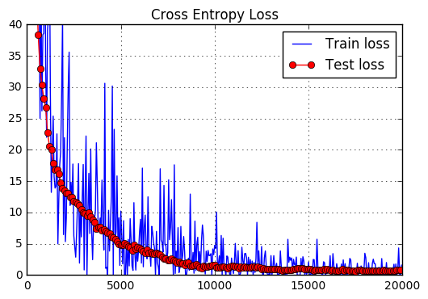

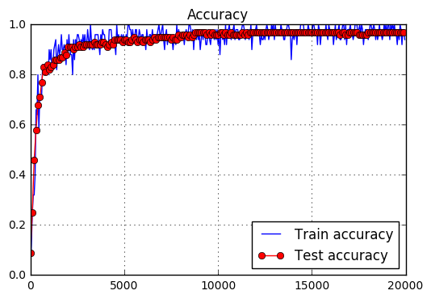

```python
import numpy as np
import matplotlib
import matplotlib.pyplot as plt
def make_loss():
    tla = np.asarray(train_loss_acc)
    plt.plot(tla[:,0],tla[:,1],label='Train loss')
    tela = np.asarray(test_loss_acc)
    plt.plot(tela[:,0],tela[:,1],"ro-",label='Test loss')
    plt.ylim(0,40)
    plt.grid(True)
    plt.title("Cross Entropy Loss")
    plt.legend()
    plt.show()

def make_acc():
    tla = np.asarray(train_loss_acc)
    plt.plot(tla[:,0],tla[:,2],label='Train accuracy')
    tela = np.asarray(test_loss_acc)
    plt.plot(tela[:,0],tela[:,2],"ro-",label='Test accuracy')
    plt.title("Accuracy")
    plt.grid(True)
    plt.legend(loc=4)
    plt.show()

make_loss()
make_acc()
```